# TX Culvert Microclimates - gtsummary practice

Leah N. Crowley

2023-09-19

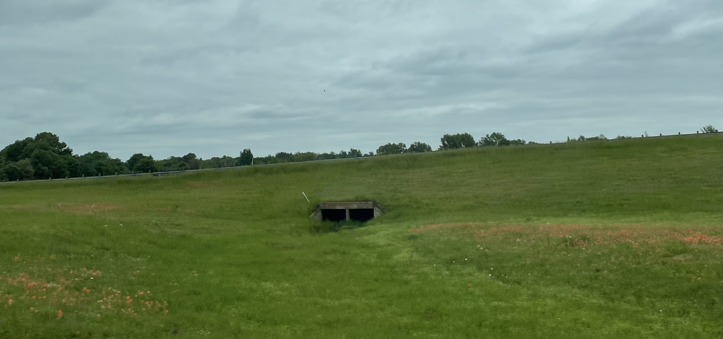

# 1. t-test Table and Figure

**t-test** For part one of this assignment, we need to carry out a **t-test**. T-tests are used to summarize and compare the means of two groups. Here, I am comparing the daily average temperatures and water vapor deficits (as well as the respective ranges and variances for each) of two culverts, named TAMU16 and TAMU8, for January, February, and March of 2023. Since this assignment focuses on using the [gtsummary](https://www.danieldsjoberg.com/gtsummary/) package to make tables, for the sake of presenting my work to the class, I will include both my code and the output in my final knitted .html file.

*Mean values were calculated for the following variables for the t-test:*

- Daily average temperature in culvert
- Daily range of culvert temperature
- Daily temperature variance in culvert
- Daily average water vapor deficit (DWVP) - the difference in water vapor pressure [kPa] between air and saturation at measured air temperature and relative humidity; higher water loss seen in WNS+ individuals)
- Daily range of DWVP in culvert
- Daily DWVP variance in culvert

```r
knitr::opts_chunk$set(echo = TRUE)

# t-test: compare the means of different variables from data recorded in two culverts: TAMU16 and TAMU8.
  table_texas1 <- texas %>%
    filter(site == "TAMU16" | site == "TAMU8") %>%
    select(site, daily.mean.temp, daily.temp.range, daily.temp.var, daily.mean.dwvp, daily.dwvp.range, daily.dwvp.var) %>%
    tbl_summary(
      by = site,
      missing = "no",
      digits = all_continuous() ~ 1,
      label = list(
        daily.mean.temp ~ "Daily Average Temperature (C)",
        daily.temp.range ~ "Daily Temperature Range (C)",
        daily.temp.var ~ "Daily Temperature Variance",
        daily.mean.dwvp ~ "Daily Average Water Vapor Deficit (kPa)",
        daily.dwvp.range ~ "Daily Water Vapor Deficit Range (kPa)",
        daily.dwvp.var ~ "Daily Water Vapor Deficit Variance"
      ),
    statistic = list(all_continuous() ~ "{mean} ({sd})",
                     all_categorical() ~ "{n}")) %>%
      add_p(pvalue_fun = ~ style_pvalue(.x, digits = 2)) %>%
      modify_caption("Table 1. TX: Average Daily Culvert Temperature Over Winter") %>%
      modify_header(
        update = list(
          label ~ '',
          stat_1 ~ '**TAMU16**',
          stat_2 ~ '**TAMU8**',
          p.value ~ '**P-value**'))

# Output to show table with results:
  table_texas1
```

Table 1. TX: Average Daily Culvert Temperature Over Winter

|  | **TAMU16**<sup>1</sup> | **TAMU8**<sup>1</sup> | **P-value**<sup>2</sup> |
| --- | --- | --- | --- |
| Daily Average Temperature (C) | 20.6 (3.0) | 18.8 (2.7) | <0.001 |
| Daily Temperature Range (C) | 5.3 (5.1) | 10.2 (7.5) | <0.001 |
| Daily Temperature Variance | 4.6 (9.1) | 17.8 (23.6) | <0.001 |
| Daily Average Water Vapor Deficit (kPa) | 1.4 (0.4) | 0.7 (0.6) | <0.001 |
| Daily Water Vapor Deficit Range (kPa) | 0.6 (0.7) | 1.0 (0.9) | 0.001 |
| Daily Water Vapor Deficit Variance | 0.1 (0.1) | 0.2 (0.2) | 0.002 |

<sup>1</sup> Mean (SD)  
<sup>2</sup> Wilcoxon rank sum test

**t-test results** This table displays calculated means for each variable under their respective culvert, followed by the standard deviation in parenthesis. The p-values associated with the t-tests for each variable are shown on the right column. In this case, a Wilcoxon rank sum test was used, as my data was not normal. Looking at the table, it seems that all t-tests that were performed yielded statistically significant results, meaning that **culverts TAMU16 and TAMU8 had distinct differences in their daily average temperatures and water vapor deficits** (and their respective ranges and variances). The following ggplot figure visualizes these results.

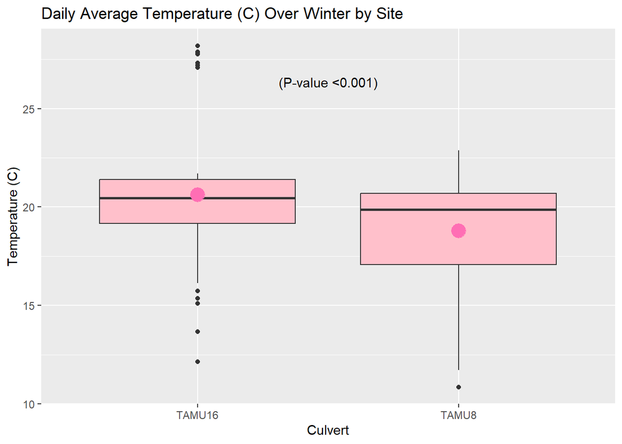

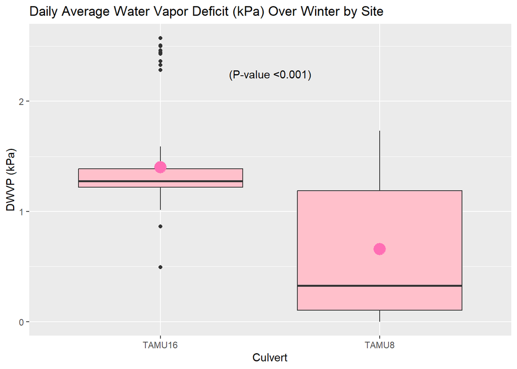

# 2. ANOVA Table and Figure

**ANOVA** For part two of this assignment, we need to carry out an **ANOVA**. We use ANOVAs to analyse differences in means between three or more groups. Here, I will expand on my t-test by including a few more culverts - TAMU27 and TAMU74. I will use the same variables for my ANOVA: the daily average temperatures and water vapor deficits (as well as the respective ranges and variances for each) for all four culverts over winter.

```r
knitr::opts_chunk$set(echo = TRUE)

#ANOVA: comparing means between three or more groups
  table_texas2 <- texas %>%
    filter(site == "TAMU16" | site == "TAMU8" | site == "TAMU27" | site == "TAMU74") %>%
    select(site, daily.mean.temp, daily.temp.range, daily.temp.var, daily.mean.dwvp, daily.dwvp.range, daily.dwvp.var) %>%
    tbl_summary(
      by = site,
      missing = "no",
      digits = all_continuous() ~ 1,
      label = list(
        daily.mean.temp ~ "Daily Average Temperature (C)",
        daily.temp.range ~ "Daily Temperature Range (C)",
        daily.temp.var ~ "Daily Temperature Variance",
        daily.mean.dwvp ~ "Daily Average Water Vapor Deficit (kPa)",
        daily.dwvp.range ~ "Daily Water Vapor Deficit Range (kPa)",
        daily.dwvp.var ~ "Daily Water Vapor Deficit Variance"
      ),
      statistic = list(all_continuous() ~ "{mean} ({sd})",
                       all_categorical() ~ "{n}")
    ) %>%
    add_p(pvalue_fun = ~ style_pvalue(.x, digits = 2)) %>%
    modify_caption("Table 2. Culvert Temperatures and Water Vapor Deficits Over Winter") %>%
    modify_footnote(everything() ~ NA) %>%
    modify_header(
      update = list(
        label ~ '',
        stat_1 ~ '**TAMU16**',
        stat_2 ~ '**TAMU8**',
        stat_3 ~ '**TAMU74**',
        stat_4 ~ '**TAMU27**',
        p.value ~ '**P-value**'))

# Output to show table with results:
  table_texas2
```

Table 2. Culvert Temperatures and Water Vapor Deficits Over Winter

[output not shown]

[figure not shown]

# 3. ANCOVA Table and Figure

| **Characteristic** | **Negative**, N = 62,786<sup>1</sup> | **Positive**, N = 59,596<sup>1</sup> | **Adjusted Difference**<sup>2</sup> | **95% CI**<sup>2,3</sup> | **p-value**<sup>2</sup> |
| --- | --- | --- | --- | --- | --- |
| dWVP.mean | 0.4 (0.3, 0.6) | 0.1 (0.0, 0.1) | 0.37 | 0.36, 0.37 | <0.001 |
| Temp.mean | 16.4 (14.1, 17.3) | 11.2 (8.7, 13.6) | 4.9 | 4.9, 4.9 | <0.001 |

<sup>1</sup> Median (IQR)  
<sup>2</sup> ANCOVA  
<sup>3</sup> CI = Confidence Interval

**ANCOVA results**

```
##
## Call:
## lm(formula = Temp.mean ~ dWVP.mean + WNS.status, data = allofit)
##
## Residuals:
##      Min       1Q   Median       3Q      Max
## -10.5008  -2.0035   0.2361   2.0726  11.9392
##
## Coefficients:
##                    Estimate Std. Error t value Pr(>|t|)
## (Intercept)        15.01784    0.01974  760.83   <2e-16 ***
## dWVP.mean           1.86296    0.03613   51.56   <2e-16 ***
## WNS.statusPositive -4.20630    0.02001 -210.26   <2e-16 ***
## ---
## Signif. codes:  0 '***' 0.001 '**' 0.01 '*' 0.05 '.' 0.1 ' ' 1
##
## Residual standard error: 2.621 on 122379 degrees of freedom
## Multiple R-squared:  0.4711, Adjusted R-squared:  0.4711
## F-statistic: 5.451e+04 on 2 and 122379 DF,  p-value: < 2.2e-16
```

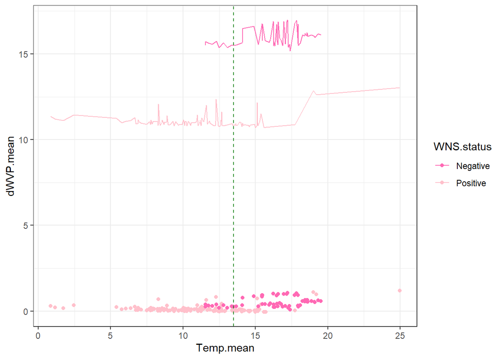